# Programming Assignment 3

## 3.

The given signal is: \begin{equation*} x[n] = \sum_{m=-\infty}^{\infty}\{4 \delta[n-4m]+ 8 \delta[n-1-4 m]\} \end{equation*} Now we shall find the DTFT coefficients for a period of the given signal. Since we are considering only a single period of the signal, the signal is aperiodic and will correspond to a periodic and continuous frequency domain representation. The following result shall be used for defining the same:

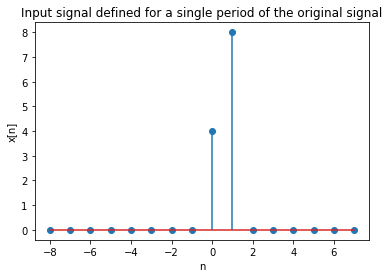

```python
import math
import numpy as np
import collections
import matplotlib.pyplot as plt

x=np.arange(-8,8)
def delta(x):
    if x.is_integer():
        return 1
    else:
        return 0
y=[]
for n in x:
    if n<4 and n>=0:
        y.append(4*delta(n/4)+8*delta((n-1)/4))
    else:
        y.append(0)
plt.title("Input signal defined for a single period of the original signal")
plt.xlabel("n")
plt.ylabel("x[n]")
plt.stem(x,y)
plt.show()
```

We shall now use the following relations to compute the DTFT coefficients of the given signal. We shall plot the real and imaginary parts of the coefficient separately with the frequency being the dependant variable. The following results are used to compute the coefficients:

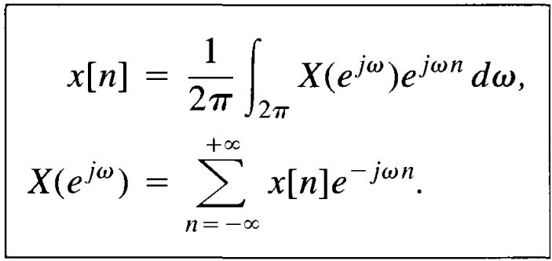

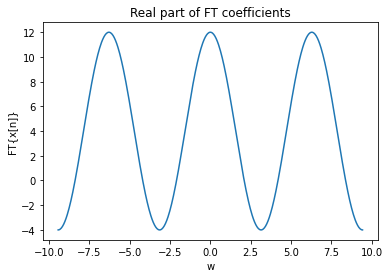

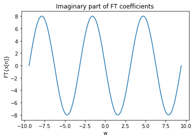

```python
omega=np.linspace(-3*np.pi,3*np.pi,500)

def ftCoefficients(y):
    x_FT = []

    for w in omega:
        data = 0
        for i in range(len(x)):
            data += y[i]*np.exp(-1j*w*x[i])
        x_FT.append(data)
    return x_FT

x_FT = ftCoefficients(y)
x_FT_R = []
x_FT_I = []
for data in x_FT:
    x_FT_R.append(data.real)
    x_FT_I.append(data.imag)
plt.title("Real part of FT coefficients")
plt.xlabel("w")
plt.ylabel("FT{x[n]}")
plt.plot(omega,x_FT_R)

plt.show()
plt.title("Imaginary part of FT coefficients")
plt.xlabel("w")
plt.ylabel("FT{x[n]}")
plt.plot(omega,x_FT_I)

plt.show()
```

The real part of coefficients must be even function and periodic while the imaginary part must be odd and periodic which is evident from the above plot.

### Properties of DTFT

We shall now verify the following properties of DTFT for the given signal in the way similar to the one in previous case.  
Our strategy remains the same and is to verify it is to get the coefficients of the DTFS in 2 ways -

- By doing an operation on the signal in the time domain - Case 1
- By doing the corresponding operation on the coefficients - Case 2

##### Time shifting property

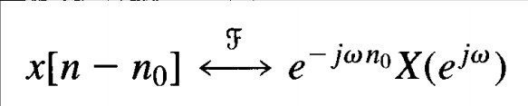

```
Real parts
```

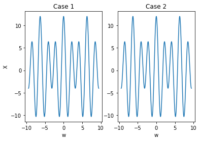

```
Imaginary parts
```

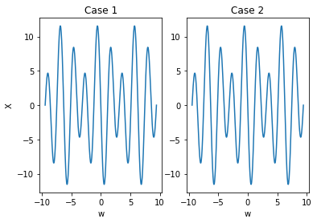

```python
#properties of DTFT
#time shifting
n0=2
yn=[]
for n in x:
    if n-n0>=0 and n-n0<4:
        yn.append(4*delta((n-n0)/4)+8*delta((n-n0-1)/4))
    else:
        yn.append(0)
x_FTn = ftCoefficients(yn)
temp=[]
for i in range(len(omega)):
    temp.append(x_FT[i]*np.exp(-1j*omega[i]*n0))

def nullChecker(n):
    if n < 1/math.pow(10,10) and n > -1/math.pow(10,10) and n!=0:
        return 0
    return n

def plotter(temp,ftn,w,label):
    tempR = []
    tempI = []
    ftnR = []
    ftnI = []
    for i in range(len(temp)):
        tempR.append(temp[i].real)
        tempI.append(nullChecker(temp[i].imag))
        ftnR.append(ftn[i].real)
        ftnI.append(nullChecker(ftn[i].imag))
    print("Real parts")
    plt.subplot(1,2,1)
    plt.plot(w,ftnR)
    plt.title("Case 1")
    plt.xlabel('w')
    plt.ylabel('X')
    plt.subplot(1,2,2)
    plt.plot(w,tempR)
    plt.title("Case 2")
    plt.xlabel('w')
#     plt.title(label)
    plt.show()
    print("Imaginary parts")
    plt.subplot(1,2,1)
    plt.plot(w,ftnI)
    plt.title("Case 1")
    plt.xlabel('w')
    plt.ylabel('X')
    plt.subplot(1,2,2)
    plt.plot(w,tempI)
    plt.title("Case 2")
    plt.xlabel('w')
#     plt.title(label)
    plt.show()
plotter(temp,x_FTn,omega,"time shift")
```

As it is visible, the plots in the two cases are evidently the same. Hence, the property is verified

##### Linearity

To demonstrate linearity, we shall take $yl[n] = y[n] + yn[n]$ and use the strategy discussed already

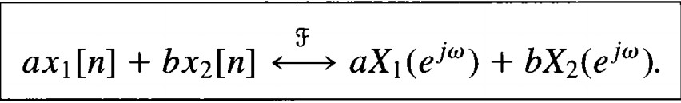

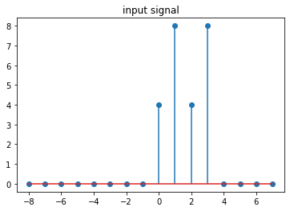

```
Real parts
```

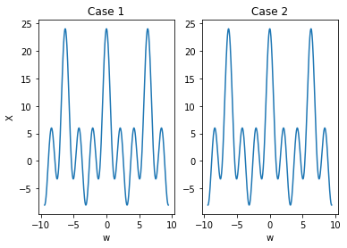

```
Imaginary parts
```

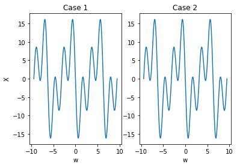

```python
#linearity
#x[n] and x[n-no] are input signals
yl=[y[i]+yn[i] for i in range(len(x))]
plt.stem(x,yl)
plt.title("input signal")
plt.show()
FTl = ftCoefficients(yl)
temp=[x_FT[i]+x_FTn[i] for i in range(len(omega))]
plotter(temp,FTl,omega,"linearity")
```

As it is visible, the plots in the two cases are evidently the same. Hence, the property is verified

##### Frequency Shifting

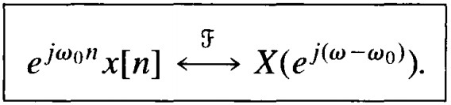

```
Real parts
```

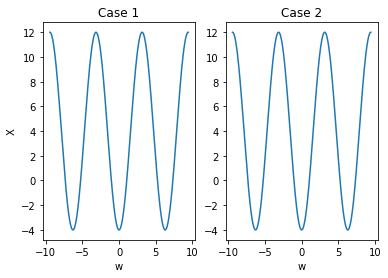

```
Imaginary parts
```

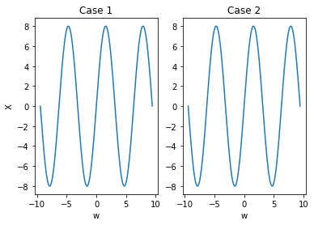

```python
w0 = np.pi
x_FTw = []
for w in omega:
        data = 0
        for i in range(len(x)):
            data += y[i]*np.exp(-1j*(w-w0)*x[i])
        x_FTw.append(data)

def FTcoeff(y,w):
    data = 0
    for i in range(len(x)):
        data += y[i]*np.exp(-1j*w*x[i])
    return data
temp = []
for w in omega:
    temp.append(FTcoeff(y,w-w0))

plotter(temp,x_FTw,omega,"periodicity")
```

As it is visible, the plots in the two cases are evidently the same. Hence, the property is verified

##### Periodicity

We basically perform a frequency shift of 2pi

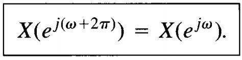

```
Real parts
```

```
Imaginary parts
```

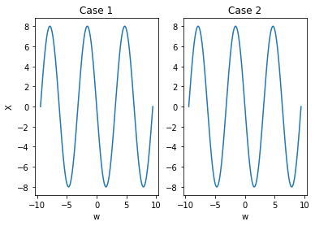

```python
w0 = 2*np.pi
x_FTw = []
for w in omega:
        data = 0
        for i in range(len(x)):
            data += y[i]*np.exp(-1j*(w+w0)*x[i])
        x_FTw.append(data)

plotter(x_FT,x_FTw,omega,"periodicity")
```

[output not shown]

As it is visible, the plots in the two cases are evidently the same. Hence, the property is verified

##### Difference Property

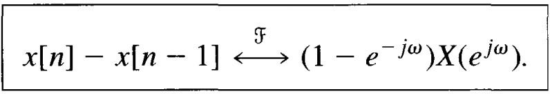

```
Real parts
```

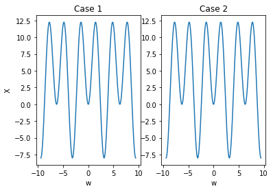

```
Imaginary parts
```

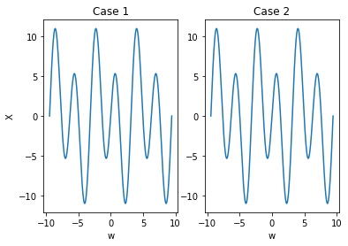

```python
#difference property
no=1
yn=[]
# print(x)
for n in x:
    if n-no<4 and n-no>=0:
        yn.append(4*delta((n-no)/4)+8*delta((n-no-1)/4))
    else:
        yn.append(0)
ydiff=[y[i]-yn[i] for i in range(len(y))]
x_FTdiff = ftCoefficients(ydiff)
temp=[]
for i in range(len(omega)):
    temp.append((1-np.exp(-1j*omega[i]))*x_FT[i])
plotter(temp,x_FTdiff,omega,"periodicity")
```

As it is visible, the plots in the two cases are evidently the same. Hence, the property is verified

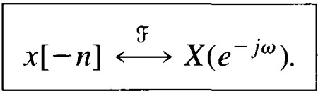

##### Symmetry property

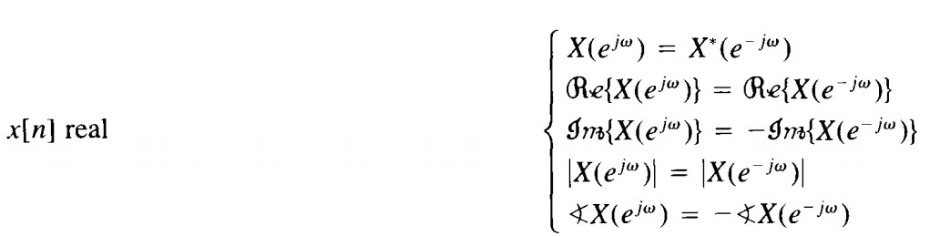

```
X(e^jw) = X*(e^-jw)
Real parts
```

```
Imaginary parts
```

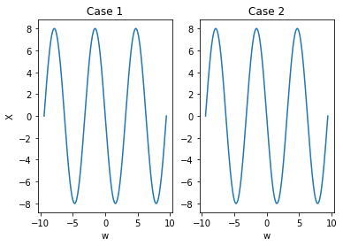

```
Re(X(e^jw)) = Re (X(e^-jw))
Im(X(e^jw)) = -Im(X(e^-jw))
Real parts
```

```
Imaginary parts
```

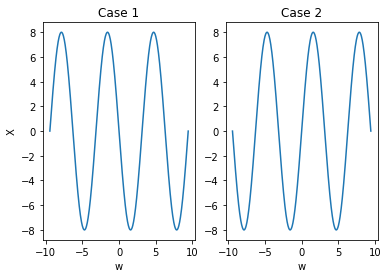

```python
#symmetry
def symmft(y):
    x_FT = []
    for w in omega:
        data = 0
        for i in range(len(x)):
            data += y[i]*np.exp(1j*w*x[i])
        x_FT.append(data)
    return x_FT

FTsy=symmft(y)
FTsy1=[np.conj(i) for i in FTsy]
print("X(e^jw) = X*(e^-jw)")
plotter(FTsy1,x_FT,omega,"symmetry property")
print("Re(X(e^jw)) = Re (X(e^-jw))")
print("Im(X(e^jw)) = -Im(X(e^-jw))")
plotter(FTsy,x_FT,omega,"symmetry property")
```

[output not shown]

##### Multiplication Property

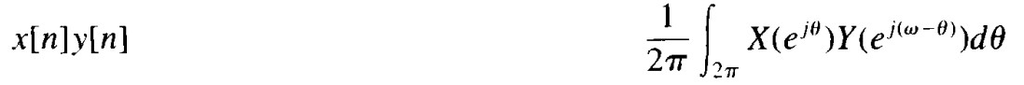

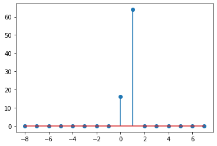

```
Real parts
```

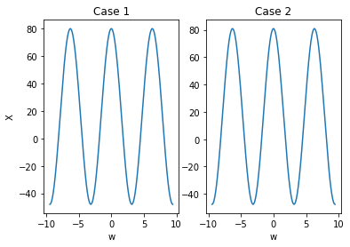

```
Imaginary parts
```

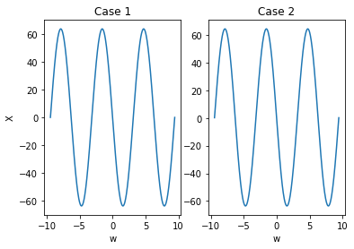

```python
y_multiplication = []
for i in range(len(y)):
    y_multiplication.append(y[i]*yl[i])
plt.stem(x,y_multiplication)
plt.show()
ft_multiplication = ftCoefficients(y_multiplication)
temp_multiplication = []
for w in omega:
    data = 0
    for t in range(len(omega)):
        if omega[t] >=0 and omega[t] <= 2*np.pi:
            data+= FTcoeff(y,t)*FTcoeff(yl,w-t)*(6*np.pi/500)
        if omega[t] > 2*np.pi:
            break
    temp_multiplication.append(data/(np.pi*2))
plotter(temp_multiplication,ft_multiplication,omega,"multiplication property")
```

As it is visible, the plots in the two cases are evidently the same. Hence, the property is verified

##### Convolution Property

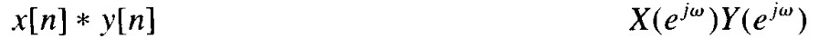

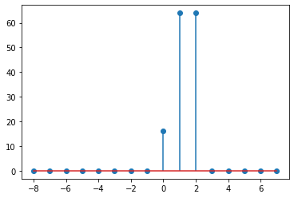

```
Real parts
```

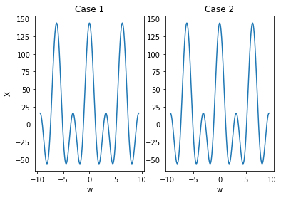

```
Imaginary parts
```

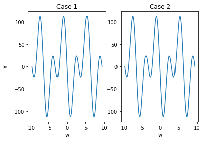

```python
y_convolution = []
for i in range(len(x)):
    data = 0
    for k in range(len(x)):
#     input signal is non-zero only at n=0,1
        if x[k] < 2 or x[k] >= 0:
            data += y[x[k]] * y[x[i]-x[k]]
    y_convolution.append(data)
x_FTconv = ftCoefficients(y_convolution)
plt.stem(x,y_convolution)
plt.show()

temp_convolution = [n*n for n in x_FT]
plotter(temp_convolution,x_FTconv,omega,"convolution property")
```

## Now we shall do some extensions of problem 3 of the assignment. In the assignment, we were limited to a period of the given signal. Let us now remove that restriction to see what happens:

## 3.

The given signal is: \begin{equation*} x[n] = \sum_{m=-\infty}^{\infty}\{4 \delta[n-4m]+ 8 \delta[n-1-4 m]\} \end{equation*} Now we shall find the DTFT coefficients for the given signal. Since the given signal is a periodic signal, the frequency domain representation will be impulses which are periodic in nature.

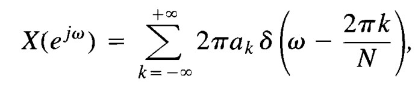

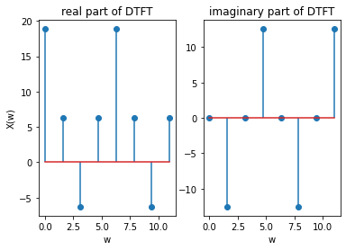

```python
import math
import numpy as np
import collections
import matplotlib.pyplot as plt

x=np.arange(0,8)

def delta(x):
    if x.is_integer():
        return 1
    else:
        return 0
#3
y=[]
for n in x:
    y.append(4*delta(n/4)+8*delta((n-1)/4))

N=4#fundamental period

def FSCoeff(y,N):
    ak=[]#fourier series coefficient
    for k in x:
        s=0
        for n in range(0,N):
            s=s+(y[n]*np.exp(-1j*k*n*np.pi/2))
        ak.append(s/4)
    return ak
ak = FSCoeff(y,N)
w=[]
for k in x:
    w.append((2*np.pi*k)/N)

ft=[2*np.pi*ak[i] for i in x]
ftr=[]
ftimg=[]
for i in ft:
    ftr.append(i.real)
    ftimg.append(i.imag)

plt.subplot(1,2,1)
plt.stem(w,ftr)
plt.xlabel('w')
plt.ylabel('X(w)')
plt.title('real part of DTFT')
plt.subplot(1,2,2)
plt.stem(w,ftimg)
plt.xlabel('w')
plt.title('imaginary part of DTFT')
plt.show()
```

### Properties of DTFT

We shall now verify the following properties of DTFT for the given signal in the way similar to the one in previous case.  
Our strategy remains the same and is to verify it is to get the coefficients of the DTFS in 2 ways -

- By doing an operation on the signal in the time domain - Case 1
- By doing the corresponding operation on the coefficients - Case 2

##### Time shifting property

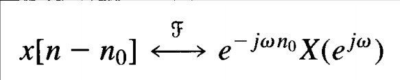

```
Real parts
```

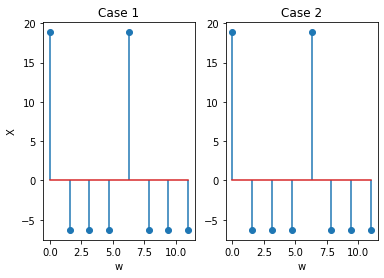

```
Imaginary parts
```

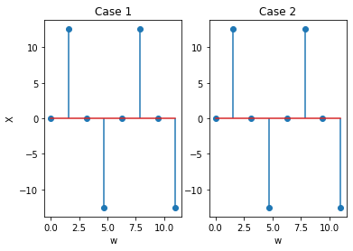

```python
#properties of DTFT
#time shifting
no=2
yn=[]
for n in x:
    yn.append(4*delta((n-no)/4)+8*delta((n-no-1)/4))

akn = FSCoeff(yn,N)
ftn=[2*np.pi*akn[i] for i in x]
temp=[]
for i in range(len(x)):
    temp.append(ft[x[i]]*np.exp(-1j*w[i]*no))

def nullChecker(n):
    if n < 1/math.pow(10,10) and n > -1/math.pow(10,10) and n!=0:
        return 0
    return n

def plotter(temp,ftn,w,label):
    tempR = []
    tempI = []
    ftnR = []
    ftnI = []
    for i in range(len(temp)):
        tempR.append(temp[i].real)
        tempI.append(nullChecker(temp[i].imag))
        ftnR.append(ftn[i].real)
        ftnI.append(nullChecker(ftn[i].imag))
    print("Real parts")
    plt.subplot(1,2,1)
    plt.stem(w,ftnR)
    plt.title("Case 1")
    plt.xlabel('w')
    plt.ylabel('X')
    plt.subplot(1,2,2)
    plt.stem(w,tempR)
    plt.title("Case 2")
    plt.xlabel('w')
#     plt.title(label)
    plt.show()
    print("Imaginary parts")
    plt.subplot(1,2,1)
    plt.stem(w,ftnI)
    plt.title("Case 1")
    plt.xlabel('w')
    plt.ylabel('X')
    plt.subplot(1,2,2)
    plt.stem(w,tempI)
    plt.title("Case 2")
    plt.xlabel('w')
#     plt.title(label)
    plt.show()
plotter(temp,ftn,w,"time shift")
```

As it is visible, the plots in the two cases are evidently the same. Hence, the property is verified

##### Linearity

To demonstrate linearity, we shall take $yl[n] = y[n] + yn[n]$ and use the strategy discussed already

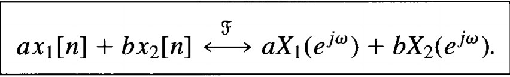

```
Real parts
```

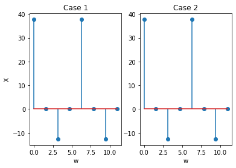

```
Imaginary parts
```

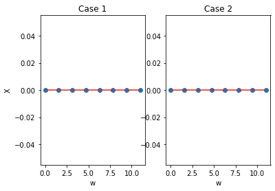

```python
yl = []
for i in range(len(yn)):
    yl.append(yn[i]+y[i])
akl = FSCoeff(yl,N)
ftl=[2*np.pi*akl[i] for i in x]
temp = []
for i in range(len(x)):
    temp.append(ftn[i]+ft[i])
plotter(temp,ftl,w,"linearity")
```

As it is visible, the plots in the two cases are evidently the same. Hence, the property is verified

##### Frequency Shifting

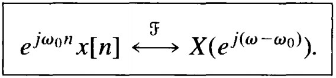

```
Real parts
```

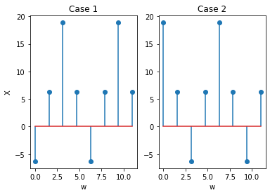

```
Imaginary parts
```

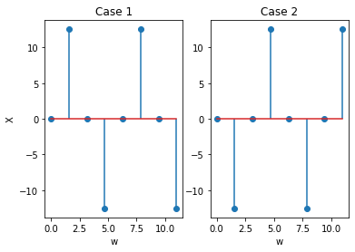

```python
w0 = np.pi
yw0 = []
for n in x:
    yw0.append((4*delta(n/4)+8*delta((n-1)/4))*np.exp(1j*w0*n))
akw0 = FSCoeff(yw0,N)
ftw0=[2*np.pi*akw0[i] for i in x]
plotter(ft,ftw0,w,"frequency shift")
```

##### Periodicity

We basically perform a frequency shift of 2pi

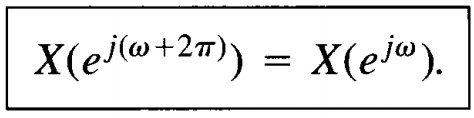

```
Real parts
```

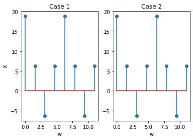

```
Imaginary parts
```

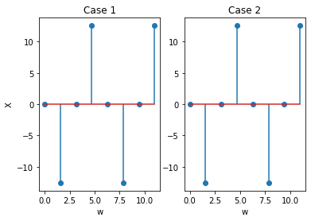

```python
w0 = 2*np.pi
yw0 = []
for n in x:
    yw0.append((4*delta(n/4)+8*delta((n-1)/4))*np.exp(1j*w0*n))
akw0 = FSCoeff(yw0,N)
ftw0=[2*np.pi*akw0[i] for i in x]
plotter(ft,ftw0,w,"periodicity")
```

As it is visible, the plots in the two cases are evidently the same. Hence, the property is verified

##### Difference Property

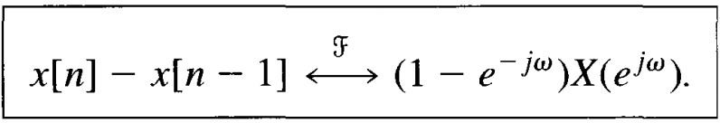

```
Real parts
```

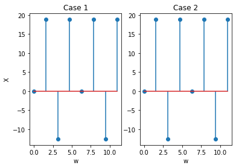

```
Imaginary parts
```

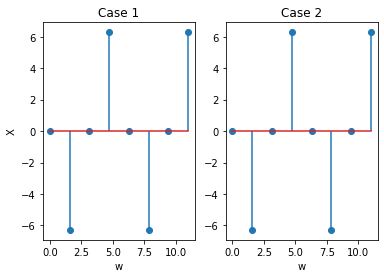

```python
#difference property
no=1
yn=[]
for n in range(-1,11):
    yn.append(4*delta((n-no)/4)+8*delta((n-no-1)/4))
ydiff=[y[i]-y[i-1] for i in x]
bk=[]
for k in x:
    s=0
    for n in range(0,N):
        s=s+(ydiff[n]*np.exp(-1j*k*n*np.pi/2))
    bk.append(s/4)
fdiff=[2*np.pi*bk[i] for i in x]
temp=[]
for i in x:
    temp.append((1-np.exp(-1j*w[i]))*ft[i])
plotter(temp,fdiff,w," ")
```

As it is visible, the plots in the two cases are evidently the same. Hence, the property is verified

##### Time Reversal

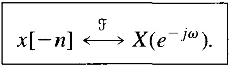

```
Real parts
```

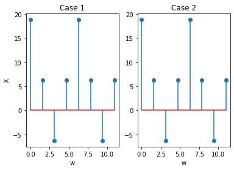

```
Imaginary parts
```

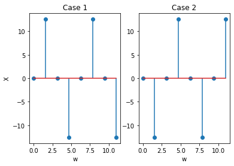

```python
#time reversal
yrev=[]
for n in x:
    yrev.append(4*delta(-1*n/4)+8*delta((-1*n-1)/4))

bk=[]
for k in x:
    s=0
    for n in range(0,N):
        s=s+(yrev[n]*np.exp(-1j*k*n*np.pi/2))
    bk.append(s/4)

frev=[2*np.pi*bk[i] for i in x]
temp=ft.copy()
plotter(temp,frev,w," ")

# plt.subplot(1,2,1)
# plt.stem(w,frev)
# plt.xlabel('w')
# plt.ylabel('X')
# plt.subplot(1,2,2)
# plt.stem(w,temp)
# plt.xlabel('w')
# plt.ylabel('X')
# plt.title('time reversal')
# plt.show()
```

##### Symmetry property

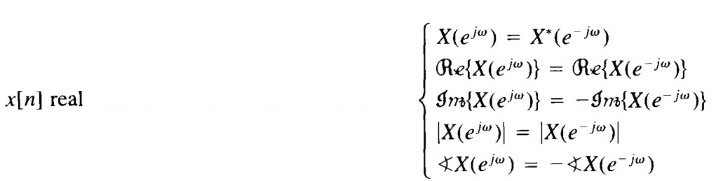

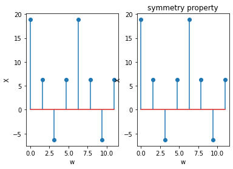

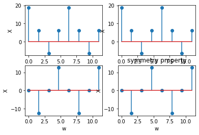

```python
#symmetry property
#x[n] is real signal
fsym=[np.conj(i) for i in frev]
plt.subplot(1,2,1)
plt.stem(w,ft)
plt.xlabel('w')
plt.ylabel('X')
plt.subplot(1,2,2)
plt.stem(w,fsym)
plt.xlabel('w')
plt.ylabel('X')
plt.title('symmetry property')
plt.show()

frevr=[]
frevimg=[]
for i in frev:
    frevr.append(i.real)
    frevimg.append(i.imag)

for i in x:
    frevimg[i]=-1*frevimg[i]
plt.subplot(2,2,1)
plt.stem(w,ftr)
plt.xlabel('w')
plt.ylabel('X')
plt.subplot(2,2,2)
plt.stem(w,frevr)
plt.xlabel('w')
plt.ylabel('X')
plt.subplot(2,2,3)
plt.stem(w,ftimg)
plt.xlabel('w')
plt.ylabel('X')
plt.subplot(2,2,4)
plt.stem(w,frevimg)
plt.xlabel('w')
plt.ylabel('X')
plt.title('symmetry property')
plt.show()
```

As it is visible, the plots in the two cases are evidently the same. Hence, the property is verified

##### Multiplication Property

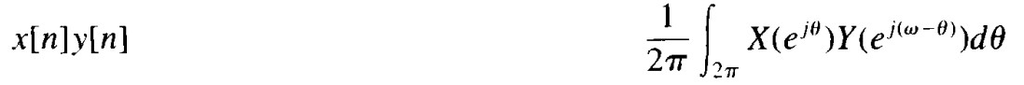

```
Real parts
```

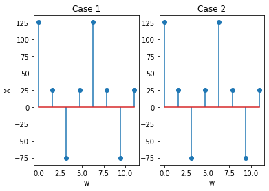

```
Imaginary parts
```

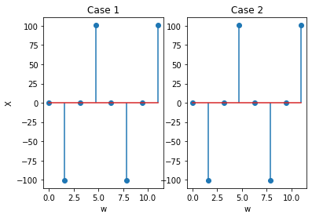

```python
y_multiplication = []
for i in range(len(y)):
    y_multiplication.append(y[i]*yl[i])
ak_multiplication = FSCoeff(y_multiplication,N)
ft_multiplication=[2*np.pi*ak_multiplication[i] for i in x]
temp_multiplication = []
def dataFinder(w0,i):
    if i-w0 < 0:
        return ft[w0]*ftl[i-w0+4]
    else:
        return ft[w0]*ftl[i-w0]
for i in x:
    data = 0
    for w0 in range(0,4):
         data += dataFinder(w0,i)
    temp_multiplication.append(data/(np.pi*2))
plotter(temp_multiplication,ft_multiplication,w,"multiplication property")
```

As it is visible, the plots in the two cases are evidently the same. Hence, the property is verified

##### Convolution Property

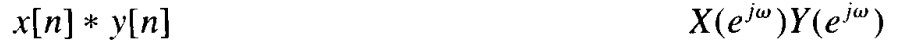

```
Real parts
```

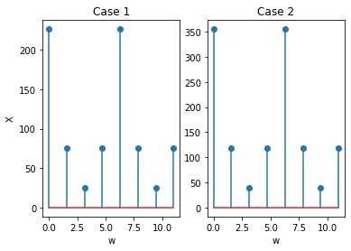

```
Imaginary parts
```

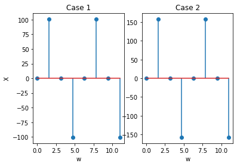

```python
y_convolution = []
def dataFinderConvolution(k,n):
     if n-k < 0:
        return y[k]*yn[n-k+4]
     return y[k]*yn[n-k]

for n in x:
    data = 0
    for k in range(N):
        data+= dataFinderConvolution(k,n)
    y_convolution.append(data)

ak_convolution = FSCoeff(y_convolution,N)
ft_convolution=[2*np.pi*ak_convolution[i] for i in x]

temp_convolution = []
for i in x:
    temp_convolution.append(ft[i]*ftn[i])
plotter(temp_convolution,ft_convolution,w,"convolution property")
```